# act_report

## Report: act_report

This report covers my analysis and visualization of the WeRateDogs dataset. After I wrangled the dataset, I came up with three insights. And I visualized one of them, which helped me examine data in a simple way.

**The first insight**

First of all, I wanted to know what is the top one popular dog name according to the dataset. I found out that it was Charlie since there were 11 different dogs sharing the same name in different tweets.

**The second insight**

In the same way as the first one but this time for the dog stages, I wanted to find out the most popular stage and used the bar chart to represent the most popular ones visually.

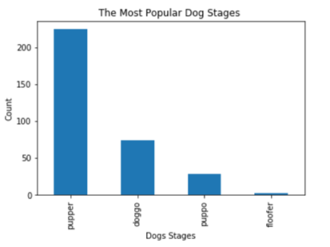

The bar chart shows the most repeated dog stage in the dataset, the x axis is for the dog stages, and the y axis counts each stage. And according to the bar chart, the Pupper stage was repeated more than 200 times and clearly the difference is obvious with the rest of the other stages.

**The third insight**

The third one I wanted to see to the most active year in which WeRateDogs was more active based on the collected data. So, it turns out that the tweets started in 2016 and the end of the tweeted was in 2017. And the year with the most tweets in the dataset is 2016.

To conclude, I discovered three insights. And I visualized one of them, which helped in my straightforward analysis of the data.